# Contingency Tables

Whitney

3/23/2020

## Example: Testing Mendel’s theories

Among its many applications, Pearson’s test was used in genetics to test Mendel’s theories of natural inheritance. Mendel crossed pea plants of pure yellow strain (dominant strain) plants of pure green strain. He predicted that second generation hybrid seeds would be 75% yellow and 25% green. One experiment produced $n = 8023$ seeds, of which $X_{1} = 6022$ were yellow and $X_{2}=2001$ were green.

- Use Pearson’s $\chi^2$ test to assess Mendel’s hypothesis.

```r
x1 = 6022; x2 = 2001; n = 8023; p1 = .75; p2 = .25
# chi square test for p1 = .75
prop.test(x1, n, p = p1, correct = F)
```

```
##
##  1-sample proportions test without continuity correction
##
## data:  x1 out of n, null probability p1
## X-squared = 0.014999, df = 1, p-value = 0.9025
## alternative hypothesis: true p is not equal to 0.75
## 95 percent confidence interval:
##  0.7410061 0.7599381
## sample estimates:
##        p
## 0.750592
```

```r
# Chi square test for p1 = .25
prop.test(x2, n, p = p2, correct = F)
```

```
##
##  1-sample proportions test without continuity correction
##
## data:  x2 out of n, null probability p2
## X-squared = 0.014999, df = 1, p-value = 0.9025
## alternative hypothesis: true p is not equal to 0.25
## 95 percent confidence interval:
##  0.2400619 0.2589939
## sample estimates:
##        p
## 0.249408
```

```r
# Z test for p1 = .75
## test statistic
zobs <- (x1 / n - p1) / sqrt((p1 * p2) / n)
zobs^2
```

```
## [1] 0.01499855
```

```r
## P-value
2 * (1 - pnorm(zobs))
```

```
## [1] 0.902528
```

```r
# Yates' continuity correction
prop.test(x1, n, p = p1)
```

```
##
##  1-sample proportions test with continuity correction
##
## data:  x1 out of n, null probability p1
## X-squared = 0.012007, df = 1, p-value = 0.9127
## alternative hypothesis: true p is not equal to 0.75
## 95 percent confidence interval:
##  0.7409430 0.7599996
## sample estimates:
##        p
## 0.750592
```

## Color preference example

In Child Psychology, color preference by young children is used as an indicator of emotional state. In astudy of 112 children, each was asked to choose favorite color from the 7 colors indicated below. Test if there is evidence of a preference at the $\alpha = .05$ level.

| Color | Blue | Red | Green | White | Purple | Black | Other |
| --- | --- | --- | --- | --- | --- | --- | --- |
| Frequency | 13 | 14 | 8 | 17 | 25 | 15 | 20 |

```r
x <- c(13, 14, 8, 17, 25, 15, 20)
chisq.test(x, correct = F)
```

```
##
##  Chi-squared test for given probabilities
##
## data:  x
## X-squared = 11, df = 6, p-value = 0.08838
```

```r
#Check
ek <- (sum(x) * 1 / length(x))
chisq <- sum((x - (sum(x) * 1 / length(x)))^2 / ek)
chisq
```

```
## [1] 11
```

```r
## P-value
1 - pchisq(chisq, 6)
```

```
## [1] 0.08837643
```

## Gender vs. Handness example

```r
x <- c(43, 9, 44, 4)
data <- matrix(x, nrow = 2, ncol = 2,
               byrow = TRUE)
dimnames(data) = list(Gender = c("M", "F"), Right = c("R", "L"))
data
```

```
##       Right
## Gender  R L
##      M 43 9
##      F 44 4
```

```r
chisq.test(data, correct = F)
```

```
##
##  Pearson's Chi-squared test
##
## data:  data
## X-squared = 1.7774, df = 1, p-value = 0.1825
```

```r
#Check
ek <- outer(rowSums(data), colSums(data)) / 100
chisq <- sum((data - ek)^2 / ek)
chisq
```

```
## [1] 1.777415
```

## Marital status example

```r
x <- c(581, 487, 455, 477)
data <- matrix(x, nrow = 2, ncol = 2,
               byrow = TRUE)
dimnames(data) = list(Child = c("M", "D"), Parent = c("M", "D"))
data
```

```
##      Parent
## Child   M   D
##     M 581 487
##     D 455 477
```

```r
chisq.test(data, correct = F)
```

```
##
##  Pearson's Chi-squared test
##
## data:  data
## X-squared = 6.2088, df = 1, p-value = 0.01271
```

## Purdue enrollment data example

The following contingency table contains enrollment data for a random sample of students from severalcolleges at Purdue University during the 2006-2007 academic year. The table lists the number of male and female students enrolled in each college. Use the two-way table to conduct a $\chi^2$ test from beginning to end. Use $\alpha = .01$.

```r
table <- matrix(c(378, 99, 104, 262, 175, 510), 3, 2)
colnames(table) <- c("Female", "Male")
rownames(table) <- c("Liberal Art", "Science", "Engineering")
table
```

```
##             Female Male
## Liberal Art    378  262
## Science         99  175
## Engineering    104  510
```

```r
chisq.test(table, correct = F)
```

```
##
##  Pearson's Chi-squared test
##
## data:  table
## X-squared = 236.47, df = 2, p-value < 2.2e-16
```

```r
library(vcd)
```

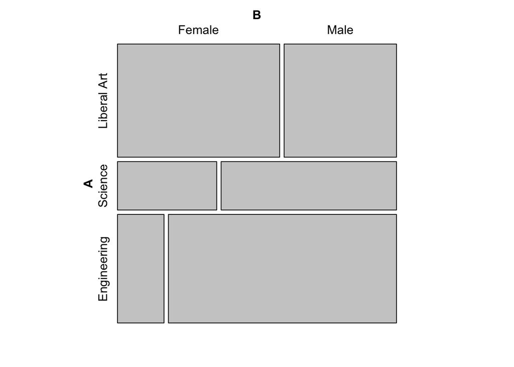

```r
mosaic(table)
```